[figure not shown]

# Your personalised newsletter

Welcome to your personalised newsletter for **August** . Here are insights and inspirations based on your recording from last month.

### A great find!

On 17/07/2019 you visited Norfolk Park, Sheffield and it was your highest DECIDE recording priority visit this month. On this visit you recorded 3 species. Our pick from these species is Holly Blue. In total, 35 records of this species were made this month by online recorders such as yourself.

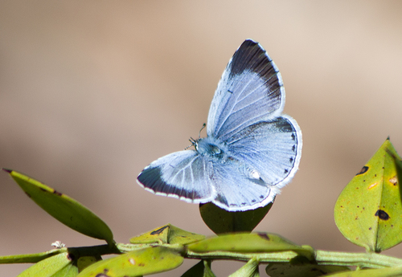

*Photo (c) katunchik, some rights reserved (CC BY), uploaded by katunchik*

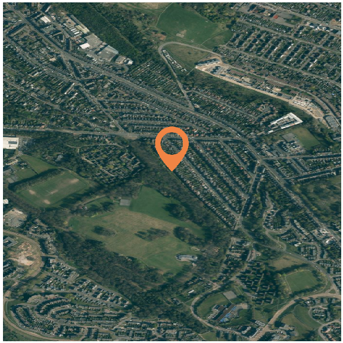

The recording priority maps in the DECIDE recorder tool responds to visits to high priority areas such as your visit to Norfolk Park, Sheffield. Check out the impact of your record on the DECIDE Recorder Tool.

[Visit the DECIDE Recorder Tool](https://decide.ceh.ac.uk/opts/scoremap/map?lat=53.371972&lon=-1.448437&score=true&popup=true&zoom=13&ds=1)

### Going the extra mile

In July you recorded in **15** different 100x100m locations and recorded a total of **23** species across these sites. Records at these sites fill gaps in our understanding of species’ distributions. Here are the 5 locations with the highest number of species you recorded.

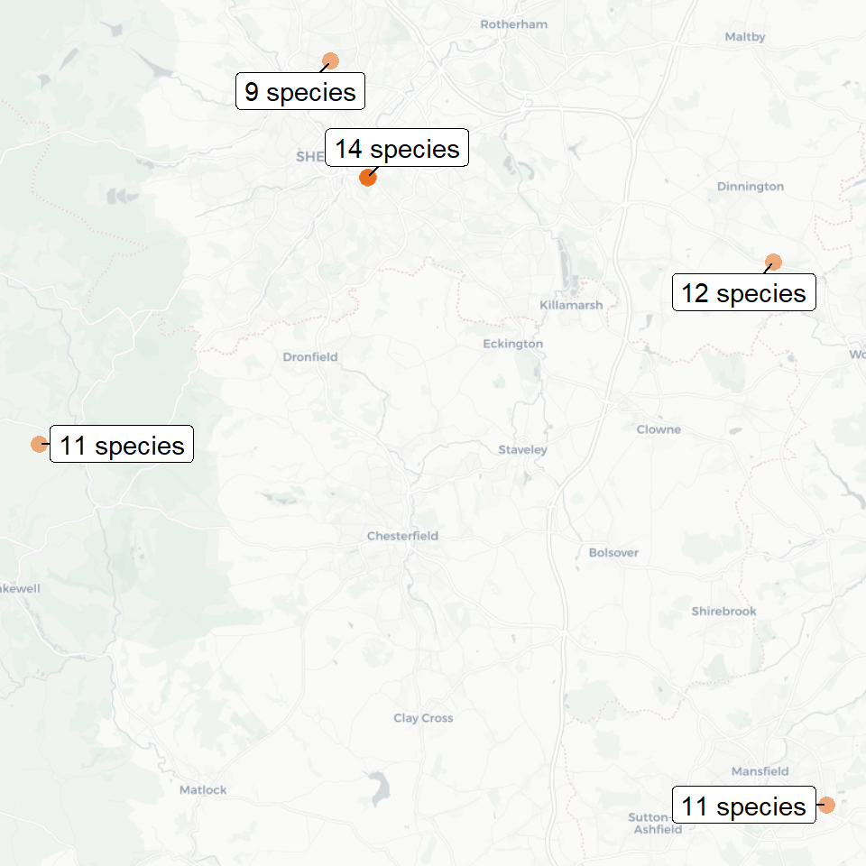

Nearby to the location you recorded the most species there are some high recording priority locations which are in need of records, why not go to one of these next time you record?

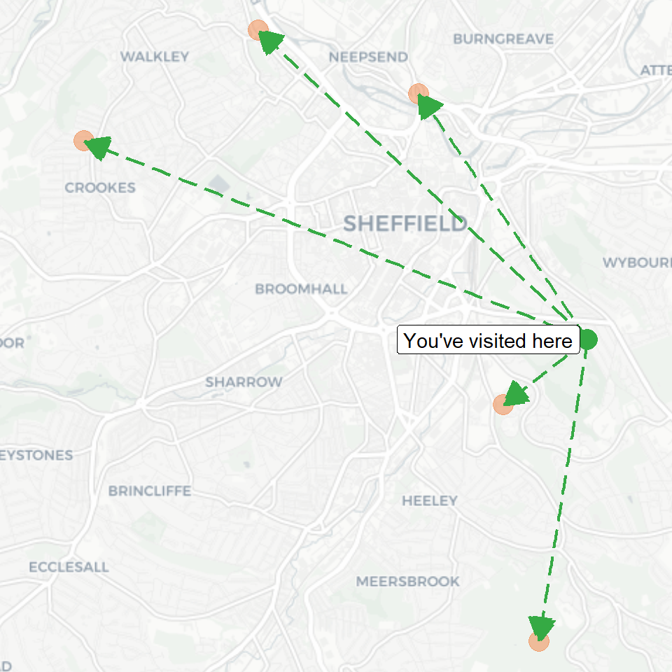

[Visit the DECIDE Recorder Tool](https://decide.ceh.ac.uk/opts/scoremap/map?lat=53.3721270816327&lon=-1.44797808163265&score=true&zoom=13&ds=2&suggestions=true)

### Other recording activity near where you recorded this month

Wildlife recording is a collective effort and by working together we can better understand species distributions. A total of 10439 butterfly records were made this month. Take a look at where people have been recording near where you record:

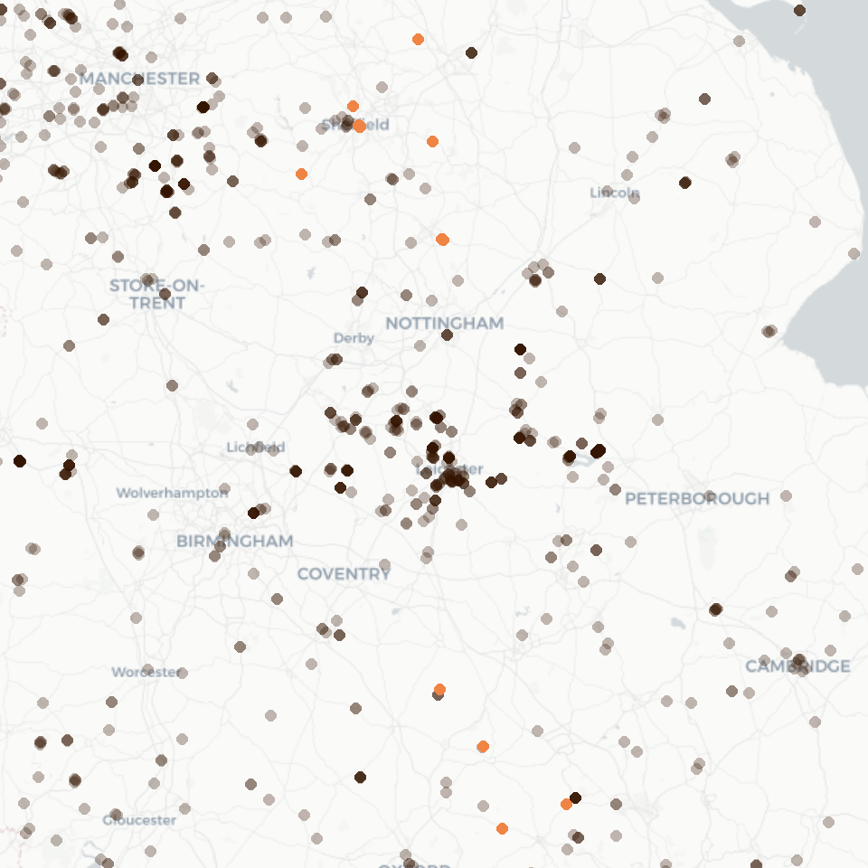

*This month's records from the DECIDE community*

Research has found that species records are unevenly distributed. Why not find high DECIDE priority location to record in and help fill the gaps in this area?

[Visit the DECIDE Recorder Tool](https://decide.ceh.ac.uk/opts/scoremap/map?lat=52.7002425&lon=-1.182112&zoom=10&ds=3)

### Your impact on improving our understanding of species distributions.

Your recording has an impact: species records improve our understanding of the distribution of species. Every visit you make increases your impact score but recording in areas with high DECIDE scores boost your impact even more! See how your records from July add up

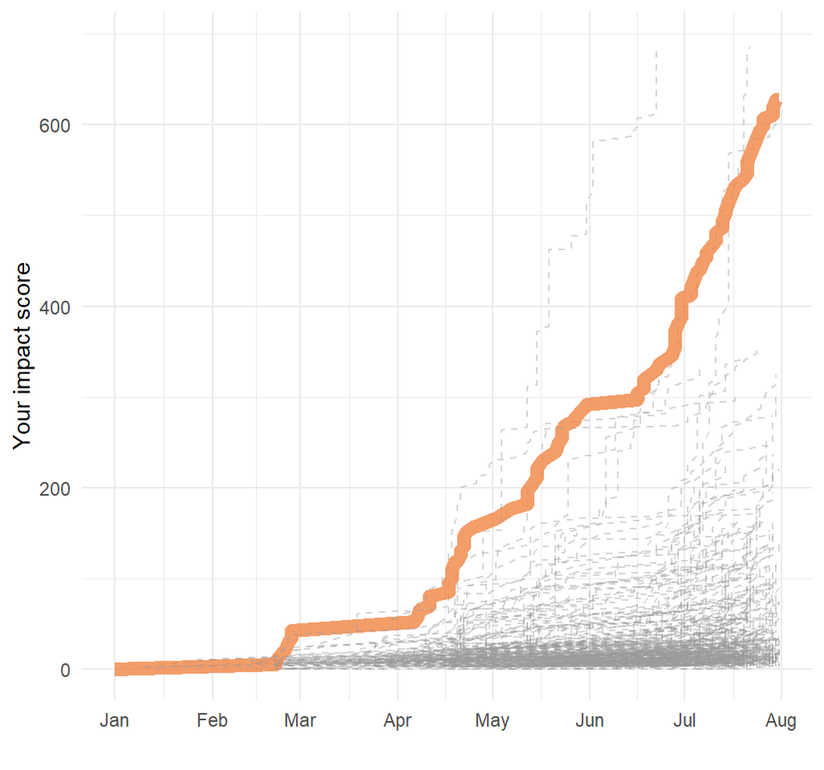

*The impact score of MyDECIDE recorders.*

Continue to build your impact by planning a visit near the last place you recorded: Norwood, Sheffield . Get suggestions for high DECIDE priority areas to record to most effectively increase your impact score.

[Visit the DECIDE Recorder Tool](https://decide.ceh.ac.uk/opts/scoremap/map?lat=53.416393&lon=-1.472086&zoom=13&ds=3&score=true&suggestions=true)

### Want to know more?

- [What and how to record](https://decide.ceh.ac.uk/info/faq_recording)
- [More about the maps and models](https://decide.ceh.ac.uk/info/faq_maps_models)
- [The DECIDE blog](https://decide.ceh.ac.uk/app/blogs)
- [About the DECIDE team](https://decide.ceh.ac.uk/info/about)

Amend your MyDECIDE personal recording details or unsubscribe from MyDECIDE. [Visit the MyDECIDE sign-up page](https://decide.ceh.ac.uk/app/newsletter)

This newsletter was generated on 2022-05-24 16:40:25